# Homework 4

Shiva Neelakantan

# PROBLEM 1

```r
library(dplyr)
insurance = read.csv('./insurance.csv')
head(insurance)
```

|  | age | gender | bmi | children | smoker | region | charges |
| --- | --- | --- | --- | --- | --- | --- | --- |
| 1 | 19 | female | 27.900 | 0 | yes | southwest | 16884.924 |
| 2 | 18 | male | 33.770 | 1 | no | southeast | 1725.552 |
| 3 | 28 | male | 33.000 | 3 | no | southeast | 4449.462 |
| 4 | 33 | male | 22.705 | 0 | no | northwest | 21984.471 |
| 5 | 32 | male | 28.880 | 0 | no | northwest | 3866.855 |
| 6 | 31 | female | 25.740 | 0 | no | southeast | 3756.622 |

## a

```r
insurance$gender = as.factor(insurance$gender)
insurance$gender = relevel(insurance$gender, ref='female')
insurance$smoker = as.factor(insurance$smoker)
insurance$smoker = relevel(insurance$smoker, ref='no')
insurance$region = as.factor(insurance$region)
insurance$region = relevel(insurance$region, ref='southwest')
str(insurance)
```

```
'data.frame':   1338 obs. of  7 variables:
 $ age     : int  19 18 28 33 32 31 46 37 37 60 ...
 $ gender  : Factor w/ 2 levels "female","male": 1 2 2 2 2 1 1 1 2 1 ...
 $ bmi     : num  27.9 33.8 33 22.7 28.9 ...
 $ children: int  0 1 3 0 0 0 1 3 2 0 ...
 $ smoker  : Factor w/ 2 levels "no","yes": 2 1 1 1 1 1 1 1 1 1 ...
 $ region  : Factor w/ 4 levels "southwest","northeast",..: 1 4 4 3 3 4 4 3 2 3 ...
 $ charges : num  16885 1726 4449 21984 3867 ...
```

## b

```r
fit = lm(charges~age+bmi+gender, insurance)
summary(fit)
```

```
Call:
lm(formula = charges ~ age + bmi + gender, data = insurance)

Residuals:
   Min     1Q Median     3Q    Max
-14974  -7073  -5072   6953  47348

Coefficients:
            Estimate Std. Error t value Pr(>|t|)
(Intercept) -6986.82    1761.04  -3.967 7.65e-05 ***
age           243.19      22.28  10.917  < 2e-16 ***
bmi           327.54      51.37   6.377 2.49e-10 ***
gendermale   1344.46     622.66   2.159    0.031 *
---
Signif. codes:  0 ‘***’ 0.001 ‘**’ 0.01 ‘*’ 0.05 ‘.’ 0.1 ‘ ’ 1

Residual standard error: 11370 on 1334 degrees of freedom
Multiple R-squared:  0.1203,    Adjusted R-squared:  0.1183
F-statistic: 60.78 on 3 and 1334 DF,  p-value: < 2.2e-16
```

## c

```r
insurance$gendermale = as.integer(insurance$gender == 'male')
males.model = lm(charges~age+bmi+gender+gendermale, subset(insurance, gender='male'))

females.model = lm(charges~age+bmi+gender+gendermale, subset(insurance, gender='female'))

summary(males.model)
```

```
Call:
lm(formula = charges ~ age + bmi + gender + gendermale, data = subset(insurance,
    gender = "male"))

Residuals:
   Min     1Q Median     3Q    Max
-14974  -7073  -5072   6953  47348

Coefficients: (1 not defined because of singularities)
            Estimate Std. Error t value Pr(>|t|)
(Intercept) -6986.82    1761.04  -3.967 7.65e-05 ***
age           243.19      22.28  10.917  < 2e-16 ***
bmi           327.54      51.37   6.377 2.49e-10 ***
gendermale   1344.46     622.66   2.159    0.031 *
gendermale        NA         NA      NA       NA
---
Signif. codes:  0 ‘***’ 0.001 ‘**’ 0.01 ‘*’ 0.05 ‘.’ 0.1 ‘ ’ 1

Residual standard error: 11370 on 1334 degrees of freedom
Multiple R-squared:  0.1203,    Adjusted R-squared:  0.1183
F-statistic: 60.78 on 3 and 1334 DF,  p-value: < 2.2e-16
```

```r
summary(females.model)
```

```
Call:
lm(formula = charges ~ age + bmi + gender + gendermale, data = subset(insurance,
    gender = "female"))

Residuals:
   Min     1Q Median     3Q    Max
-14974  -7073  -5072   6953  47348

Coefficients: (1 not defined because of singularities)
            Estimate Std. Error t value Pr(>|t|)
(Intercept) -6986.82    1761.04  -3.967 7.65e-05 ***
age           243.19      22.28  10.917  < 2e-16 ***
bmi           327.54      51.37   6.377 2.49e-10 ***
gendermale   1344.46     622.66   2.159    0.031 *
gendermale        NA         NA      NA       NA
---
Signif. codes:  0 ‘***’ 0.001 ‘**’ 0.01 ‘*’ 0.05 ‘.’ 0.1 ‘ ’ 1

Residual standard error: 11370 on 1334 degrees of freedom
Multiple R-squared:  0.1203,    Adjusted R-squared:  0.1183
F-statistic: 60.78 on 3 and 1334 DF,  p-value: < 2.2e-16
```

## d

```r
males=insurance[insurance$gender=='male', ]
females=insurance[insurance$gender=='female', ]

fit_males = lm(charges~bmi+age, males)
fit_females = lm(charges~bmi+age, females)

summary(fit_males)
```

```
Call:
lm(formula = charges ~ bmi + age, data = males)

Residuals:
   Min     1Q Median     3Q    Max
-16895  -7984  -5567   7904  47424

Coefficients:
            Estimate Std. Error t value Pr(>|t|)
(Intercept) -8012.79    2619.78  -3.059  0.00231 **
bmi           409.87      77.11   5.315 1.45e-07 ***
age           238.63      33.70   7.081 3.61e-12 ***
---
Signif. codes:  0 ‘***’ 0.001 ‘**’ 0.01 ‘*’ 0.05 ‘.’ 0.1 ‘ ’ 1

Residual standard error: 12210 on 673 degrees of freedom
Multiple R-squared:  0.1168,    Adjusted R-squared:  0.1142
F-statistic:  44.5 on 2 and 673 DF,  p-value: < 2.2e-16
```

```r
summary(fit_females)
```

```
Call:
lm(formula = charges ~ bmi + age, data = females)

Residuals:
   Min     1Q Median     3Q    Max
-10063  -5959  -4587  -1521  46239

Coefficients:
            Estimate Std. Error t value Pr(>|t|)
(Intercept) -4515.22    2286.14  -1.975 0.048681 *
bmi           241.32      67.49   3.576 0.000375 ***
age           246.92      29.03   8.504  < 2e-16 ***
---
Signif. codes:  0 ‘***’ 0.001 ‘**’ 0.01 ‘*’ 0.05 ‘.’ 0.1 ‘ ’ 1

Residual standard error: 10440 on 659 degrees of freedom
Multiple R-squared:  0.1224,    Adjusted R-squared:  0.1197
F-statistic: 45.94 on 2 and 659 DF,  p-value: < 2.2e-16
```

## e

When we have gender as a dummy variable, as seen in part c, our error for the predictors are all lower, as the model takes a categorical approach to considering the dichotomy between the male and female predictors. This finding is seen for both the male and female subsets of the insurance data.

## f

These results are not necessarily contradictory. R^2 is simply a measure of the variability in our response that can be explained by the model. There is a chance that our data are modeled by a linear relationship, but they could have a very high spread, which would increase the residual sum of squares, and in turn, the R^2 as well. Thus, although the predictors are significant, our R^2 can still be low.

================================

# PROBLEM 2

## a

Multicollinearity can present itself as a problem when making accurate predictions. This is because if two variables within a data set have a natural correlation to one another, such as, for instance, if fuel economy and engine size were two predictors, then they may introduce unwanted bias into the model, affecting the other predictors. Thus, multicollinearity can affect our ability to make accurate predictions.

## b

```r
set.seed(42)
x1 = runif(100)
x2 = 0.8*x1 + rnorm(100,0,0.1)
cor(x1, x2)
```

```
[1] 0.9404249
```

```r
Y = 3 + 2 * x1 + 4 * x2
```

## c

```r
df = data.frame(Y, x1, x2)
train = df[seq(50), ]
test = df[seq(51,100), ]
df.sim = lm(Y~x1+x2, df)
summary(df.sim)
```

```
Call:
lm(formula = Y ~ x1 + x2, data = df)

Residuals:
       Min         1Q     Median         3Q        Max
-1.534e-15 -5.296e-16 -2.378e-16  1.216e-16  1.603e-14

Coefficients:
             Estimate Std. Error   t value Pr(>|t|)
(Intercept) 3.000e+00  3.999e-16 7.501e+15   <2e-16 ***
x1          2.000e+00  1.928e-15 1.037e+15   <2e-16 ***
x2          4.000e+00  2.149e-15 1.861e+15   <2e-16 ***
---
Signif. codes:  0 ‘***’ 0.001 ‘**’ 0.01 ‘*’ 0.05 ‘.’ 0.1 ‘ ’ 1

Residual standard error: 1.969e-15 on 97 degrees of freedom
Multiple R-squared:      1, Adjusted R-squared:      1
F-statistic: 3.534e+31 on 2 and 97 DF,  p-value: < 2.2e-16
```

```r
test.mse = mean((test$Y - predict.lm(df.sim, test)) ^ 2)
test.mse
```

```
[1] 6.03873e-30
```

## d

```r
mse.all = c()
for (i in seq(2500)) {
  x1 = runif(100)
  x2 = 0.8*x1 + rnorm(100,0,0.1)
  Y = 3 + 2 * x1 + 4 * x2
  df = data.frame(Y, x1, x2)
  train.split = df[seq(50), ]
  test.split = df[seq(51,100), ]
  model = lm(Y~., train.split)
  test.mse = mean((test.split$Y - predict.lm(model, test.split)) ^ 2)
  mse.all = append(mse.all, test.mse)
}
mean(mse.all)
```

```
[1] 3.086634e-30
```

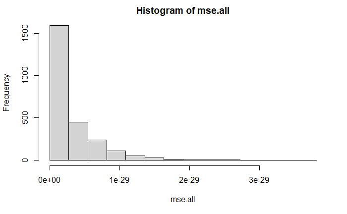

```r
hist(mse.all, breaks = seq(min(mse.all), max(mse.all), length.out = 15))
```

The MSEs are skewed to the right; the vast majority of test MSEs are close to 0, with a little bit of spread.

## e

```r
set.seed(24)
x1 = runif(100)
x2 = rnorm(100,0,1)
Y = 3 + 2 * x1 + 4 * x2
cor(x1, x2)
```

```
[1] 0.03316596
```

## f

```r
mse.all = c()
for (i in seq(2500)) {
  x1 = runif(100)
  x2 = rnorm(100,0,1)
  Y = 3 + 2 * x1 + 4 * x2
  df = data.frame(Y, x1, x2)
  train.split = df[seq(50), ]
  test.split = df[seq(51,100), ]
  model = lm(Y~., train.split)
  test.mse = mean((test.split$Y - predict.lm(model, test.split)) ^ 2)
  mse.all = append(mse.all, test.mse)
}
mean(mse.all)
```

```
[1] 3.738809e-30
```

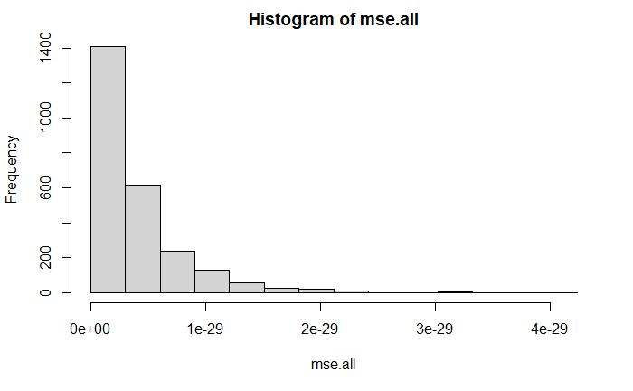

```r
hist(mse.all, breaks = seq(min(mse.all), max(mse.all), length.out = 15))
```

The observations are very similar to the previous histogram; MSEs are skewed to the right; the vast majority of test MSEs are close to 0, with a little bit of spread.

## g

We can see from the two histograms and mean MSEs that there is not much difference. Therefore, we can conclude that when the predictors have virtually no correlation, as well as when they have extremely high correlation, the prediction accuracy distribution is still pretty similar. Thus, multicollinearity did not have a significant effect on prediction accuracy.